# ALP 301: Stones2Milestones, Recommendation Systems (Exploring Cold Start Problem)

April 2021

```r
if (!require("pacman")) install.packages("pacman")
pacman::p_load(tidyverse)
pacman::p_load(here)
pacman::p_load(lmtest)
pacman::p_load(glue)
pacman::p_load(broom)
pacman::p_load(ri2)
pacman::p_load(margins)
pacman::p_load(glmnet)
pacman::p_load(kableExtra)
pacman::p_load(stargazer)
pacman::p_load(knitr)
pacman::p_load(doParallel)
pacman::p_load(corrplot)

rm(list = ls())
```

## Introduction: Cold Start Recommendation

In previous tutorials, the majority of methods we tried belong to collaborative filtering, i.e. using the user-item interaction data. As you might be aware, collaborative filtering suffers from the cold-start problem: there is no data for new users or new items, and so the algorithm (a) cannot make recommendations for new users; (b) cannot include new items into the recommended list for users.

In many industry settings, people would deploy specific “cold-start strategies” to tackle this problem. For new users, recommend popular items to them until we’ve gathered enough data about the user to be able to personalize; for new items, recommend them only to frequent users until some point, etc.

The obvious question is, how to define “new” users/items here? After gathering how many interactions should we consider the user/item to be no longer “new”, and switch to personalization? In this tutorial, we will use data analysis to find out the best way to recommend new items (stories).

```r
# Note for 2021 data (coverage: 2020-05-01 to 2021-01-31):
## filter60 means that we filtered out interactions involving
# children who made fewer than 60 interactions;
# after filtering, there are 11202 users left.

# read story characteristics
story_info<- read_csv("Datasets/all_story_obs.csv")

# read utility matrix
utility_mat<- read_csv("Datasets/utils_mat_filtered.csv",col_types = cols(.default = col_double()))
# number of columns in the utility_mat
num_cols <- 2527

child_ids<-as.integer(utility_mat$child_id_code)
story_ids<-as.integer(colnames(utility_mat[,3:num_cols]))

# only use stories with features available
stories_with_features<-(story_ids %in% story_info$story_id_code)

# discard first two columns of utility_mat (which are index and child_id_code)
utility_matrix<-utility_mat[,3:num_cols]

# only retain stories with features available to us
utility_matrix<-utility_matrix[,stories_with_features]

# story_ids; this is not sequential and thus different from column index numbers
story_ids<-colnames(utility_matrix)

# turn utility_matrix into R matrix format
utility_matrix<-as.matrix(utility_matrix)

rm(utility_mat)  # this variable is no longer needed
```

The following are the algorithms we’re using, as well as the definition of precision tests:

```r
# return X recommendations based on item-item similarity matrix
Item_based_top_X_recommendations<-function(uservector, X, similarity_mat){
  index_known<-which(uservector!=0) #Get the indices of stories known.
  # get the indexes of stories that the user has not interacted with
  index_unknown<-uservector==0
  if(length(index_known)>1){  # sum up the similarity scores for all stories known
    item_scores<-colSums(similarity_mat[index_known,])
  }else{
    item_scores<-(similarity_mat[index_known,])
  }
  # from the indexes, get the column labels for the recommended items
  names_unknown<-story_ids[index_unknown]
  # sort by the item scores to get the top recommended items
  index <- which(item_scores[index_unknown] >= sort(item_scores[index_unknown], decreasing=T)[X], arr.ind=TRUE)
  return(names_unknown[index])
}

# get the predicted utility scores for stories that the user has interacted with
All_Item_Scores_IBCF<-function(uservector){
  index_known<-which(uservector!=0) #Get the indices of stories known.
  if(length(index_known)>1){  # sum up the similarity scores for all stories known
    item_scores<-colSums(similarity_matrix[index_known,])
  }else{
    item_scores<-(similarity_matrix[index_known,])
  }
  return(item_scores)
}
```

```r
# calculates the content-based recommendations
Story_char_based_top_X_recommendations<-function(uservector, story_char_mat, X){
  index_known<-which(uservector!=0) #Get the indices of stories known.
  index_unknown<-uservector==0
  if(length(index_known)>1){
    # sum up the similarity scores for all stories known, then normalize
    item_scores<-colSums(story_char_mat[index_known,])/ncol(story_char_mat[index_known,])
  }else{
    item_scores<-(story_char_mat[index_known,])
  }
  # from the indexes, get the column labels for the recommended items
  names_unknown<-story_ids[index_unknown]

  # sort by the item scores to get the top recommended items
  index <- which(item_scores[index_unknown] >= sort(item_scores[index_unknown], decreasing=T)[X], arr.ind=TRUE)
  return(names_unknown[index])
}

# calculate the predicted scores for the item pairs
All_Item_Scores_Story_char_filter<-function(uservector){
  index_known<-which(uservector!=0) #Get the indices of stories known.
  if(length(index_known)>1){
    item_scores<-(colSums(similarity_matrix_story_info[index_known,])/ncol(similarity_matrix_story_info[index_known,]))
  }else{
    item_scores<-(similarity_matrix_story_info[index_known,])
  }
  return(item_scores)
}
```

```r
#All but K approach and RMSE, testing function:
test_all_but_k_items<-function(k,ratings_matrix,similarity_mat){
  precision_vector<-vector()
  recall_vector<-vector()
  rmse_vector<-vector()
  for (userid in 1:nrow(ratings_matrix)){
    # ratings of a user
    user=ratings_matrix[userid,]
    # items that the user has interacted with
    index_of_known<-which(user!=0 )
    if(length(index_of_known)>k){
      # hold out some items
      takeout<-sample(1:length(index_of_known),size=k)
      # indexes of stories held out
      stories_removed<-index_of_known[takeout]
      # save the utilities of the held-out items
      save_old<-user[stories_removed]
      # then set these held-out utilities to be 0
      user[stories_removed]<-0
      # restore the user's ratings in the ratings matrix
      ratings_matrix[userid,]<-user
      # get recommended items
      recommended<-Item_based_top_X_recommendations(user, k, similarity_mat)
      # calculate how many rec'ed items match the held-out items
      matched=length(intersect(story_ids[stories_removed],recommended))
      # calculate precision and recall
      precision_vector<-append(precision_vector,matched/k)
      recall_vector<-append(recall_vector,(matched/(length(index_of_known))))
      # restore the held-out items in the ratings matrix (not used for tutorial 05)
      user[stories_removed]<-save_old
      ratings_matrix[userid,]<-user
      # get the predicted utilities to calculate RMSE (not used for tutorial 05)
      itemscores<-All_Item_Scores_Story_char_filter(ratings_matrix[userid,])
      rmse<- sqrt(mean((ratings_matrix[userid,]-itemscores)^2))
      rmse_vector<-append(rmse_vector,rmse)
    }
  }
  return(c("Precision"=mean(precision_vector),"Recall"=mean(recall_vector), "RMSE"=mean(rmse_vector)))
}
```

```r
#All but K approach and RMSE, testing function:
test_all_but_k_storychars<-function(k,ratings_matrix, story_char_mat){
  precision_vector<-vector()
  recall_vector<-vector()
  rmse_vector<-vector()
  for (userid in 1:nrow(ratings_matrix)){
    # ratings of a user
    user=ratings_matrix[userid,]
    # items that the user has interacted with
    index_of_known<-which(user!=0)
    if(length(index_of_known)>k){
      # hold out some items
      takeout<-sample(1:length(index_of_known),size=k)
      # indexes of stories held out
      stories_removed<-index_of_known[takeout]
      # save the utilities of the held-out items
      save_old<-user[stories_removed]
      # then set these held-out utilities to be 0
      user[stories_removed]<-0
      # restore the user's ratings in the ratings matrix
      ratings_matrix[userid,]<-user
      # get recommended items
      recommended<-Story_char_based_top_X_recommendations(user, story_char_mat, k)
      # calculate how many rec'ed items match the held-out items
      matched=length(intersect(story_ids[stories_removed],recommended))
      # calculate precision and recall
      precision_vector<-append(precision_vector,matched/k)
      recall_vector<-append(recall_vector,(matched/(length(index_of_known))))
      # restore the held-out items in the ratings matrix (not used for tutorial 05)
      user[stories_removed]<-save_old
      ratings_matrix[userid,]<-user
      # get the predicted utilities to calculate RMSE (not used for tutorial 05)
      itemscores<-All_Item_Scores_Story_char_filter(ratings_matrix[userid,])
      rmse<- sqrt(mean((ratings_matrix[userid,]-itemscores)^2))
      rmse_vector<-append(rmse_vector,rmse)
    }
  }
  return(c("Precision"=mean(precision_vector),"Recall"=mean(recall_vector), "RMSE"=mean(rmse_vector)))
}
```

## When to switch out of the “cold-start strategy”?

For this tutorial, we will use content filtering (which you learned about in Tutorial 03: `S2M_Recsys_basic`) as our cold-start strategy. Recall from that tutorial that available story characteristics include `level, totpage, wordcount, has_geoarea, has_color, has_fruits`, and so on.

Let’s do experiments to find out when we should switch from content filtering to collaborative filtering.

First, the function defined below applies a filter on the columns of a utility matrix, and only keep columns with number of values in the range `(filter_size, filter_size + offset)` values. Remember, the matrix consists mostly of N/A values, and the columns correspond to the stories, so we’re filtering out the stories with less than `filter_size` or more than `filter_size + offset` interactions.

```r
filterer <- function(mat, filter_size, offset) {
  cols_ret <- vector()
  n_rows <- nrow(mat)  # number of rows
  for (col in 1:ncol(mat)) {  # iterate through the columns
    n_values <- n_rows - sum(is.na(mat[,col]))  # number of stories read by this user
    if (filter_size + offset > n_values && n_values >= filter_size) {
      # if pass the filter criteria, then add this story to the list
      cols_ret <- append(cols_ret, col)
    }
  }
  return(mat[,cols_ret])
}
```

Let’s see how many columns (stories) are left in the matrix after applying the filters.

```r
offset <- 20
filter_sizes <- c(0,20,40,60,80)

stories_left <- vector()
for (filt in filter_sizes) {
  # constructing matrix
  filtered<-filterer(utility_matrix, filt, offset)
  stories_left<-append(stories_left, ncol(filtered))
}
avg_n_stories <- sum(stories_left) / length(filter_sizes)
stories_left
```

```
## [1] 31 46 54 57 66
```

From the output, we can see we get several dozen stories left in each range. For example, for range 0-20, there are 31 stories left; for range 80-100, there are 66 left.

| only keep stories with number of interactions within range | 0-20 | 20-40 | 40-60 | 60-80 | 80-100 |
| --- | --- | --- | --- | --- | --- |
| number of remaining stories after applying the filter | 31 | 46 | 54 | 57 | 66 |

Applying the filters above, the following code gets the `precision@1` scores for content filtering. Using `precision@1` means we will hold out 1 story per user, and try to predict that single held-out story.

Unlike in previous tutorials, here the number of stories for each filtered dataset changes, so the precision score is unfair—the more the number of stories in the dataset, the harder it is to precisely predict the single held-out story, and the lower precision tends to be.

To account for the unfairness, the calculated scores are normalized such that, for example, for range 0-20 (31 stories), the scores are made lower, while for range 80-100 (66 stories), the scores are made higher.

```r
precision_con <- vector()
# rmse_con<-vector()
for (filt in filter_sizes) {
  # constructing matrix
  filtered<-filterer(utility_matrix, filt, offset)
  filtered[is.na(filtered)]<-0.0
  story_ids<-colnames(filtered)

  # get the story characteristics as numeric features
  story_info%>%filter(story_id_code %in% story_ids)%>%select(one_of("totpage","wordcount",
            "has_geoarea","has_color","has_fruits",
            "has_vegetables","has_animals","has_sports",
            "story_id_code"))->story_numeric
  story_numeric<-arrange(story_numeric,story_id_code)
  story_chars_matrix<-as.matrix(story_numeric[,-1]) #Remove the ID variable

  # calculate the pairwise dot-product of between all pairs of stories
  sim1<- (story_chars_matrix) %*% t(story_chars_matrix)

  # this is needed for normalization
  sim2<- (rowSums(story_chars_matrix)) %*% t(rowSums(story_chars_matrix))

  # now all entries in the matrix encode similarity between story i and story j
  similarity_matrix_story_info <- sim1 / sim2

  # testing
  ret <- test_all_but_k_storychars(1, filtered, similarity_matrix_story_info)
  precision_con <- append(precision_con, as.numeric(ret["Precision"]))
}

# normalization: multiply each score by the number of stories associated with that
# filter, then divide by the average number of stories
precision_con <- precision_con * stories_left / avg_n_stories
precision_con
```

```
## [1] 0.2241684 0.2349746 0.1592757 0.1580713 0.1575365
```

Get the precision scores for collaborative filtering.

```r
precision_cf <- vector()

# rmse_cf<-vector()
for (filt in filter_sizes) {
  # constructing matrix
  filtered<-filterer(utility_matrix, filt, offset)
  filtered[is.na(filtered)]<-0.0
  # calculate the pairwise dot-product of between all pairs of stories
  sim1<- t(filtered) %*% (filtered)
  # this is needed for normalization
  sim2<- (colSums(filtered)) %*% t(colSums(filtered))
  # now all entries in the matrix encode similarity between story i and story j
  similarity_matrix <- sim1 / sim2
  # testing
  ret <- test_all_but_k_items(1, filtered, similarity_matrix)
  precision_cf <- append(precision_cf, as.numeric(ret["Precision"]))
}

# normalization: multiply each score by the number of stories associated with that
# filter, then divide by the average number of stories
precision_cf <- precision_cf * stories_left / avg_n_stories
precision_cf
```

```
## [1] 0.1245380 0.2063191 0.3185514 0.2798640 0.2891258
```

For baseline, here we measure the performance of a random recommender.

```r
#All but K approach and RMSE, testing function:
test_all_but_k_rand<-function(k,ratings_matrix){
  precision_vector<-vector()
  recall_vector<-vector()
  rmse_vector<-vector()
  for (userid in 1:nrow(ratings_matrix)){
    # ratings of a user
    user=ratings_matrix[userid,]
    # items that the user has interacted with
    index_of_known<-which(user!=0 )
    if(length(index_of_known)>k){
      # hold out some items
      takeout<-sample(1:length(index_of_known),size=k)
      # indexes of stories held out
      stories_removed<-index_of_known[takeout]
      # save the utilities of the held-out items
      save_old<-user[stories_removed]
      # then set these held-out utilities to be 0
      user[stories_removed]<-0
      # restore the user's ratings in the ratings matrix
      ratings_matrix[userid,]<-user
      # get random recommended items
      recommended<-sample(1:ncol(ratings_matrix),size=k)
      recommended<-story_ids[recommended]
      # calculate how many rec'ed items match the held-out items
      matched=length(intersect(story_ids[stories_removed],recommended))
      # calculate precision and recall
      precision_vector<-append(precision_vector,matched/k)
      recall_vector<-append(recall_vector,(matched/(length(index_of_known))))
      # restore the held-out items in the ratings matrix (not used for tutorial 05)
      user[stories_removed]<-save_old
      ratings_matrix[userid,]<-user
      # get the predicted utilities to calculate RMSE (not used for tutorial 05)
      itemscores<-All_Item_Scores_Story_char_filter(ratings_matrix[userid,])
      rmse<- sqrt(mean((ratings_matrix[userid,]-itemscores)^2))
      rmse_vector<-append(rmse_vector,rmse)
    }
  }
  return(c("Precision"=mean(precision_vector),"Recall"=mean(recall_vector), "RMSE"=mean(rmse_vector)))
}

precision_rand <- vector()
for (filt in filter_sizes) {
  # constructing matrix
  ret <- test_all_but_k_rand(1, filtered)
  precision_rand <- append(precision_rand, as.numeric(ret["Precision"]))
}

# normalization: multiply each score by the number of stories associated with that
# filter, then divide by the average number of stories
precision_rand <- precision_rand * stories_left / avg_n_stories
precision_rand
```

```
## [1] 0.009575747 0.012917430 0.009098363 0.011204466 0.024093814
```

Plot the results here:

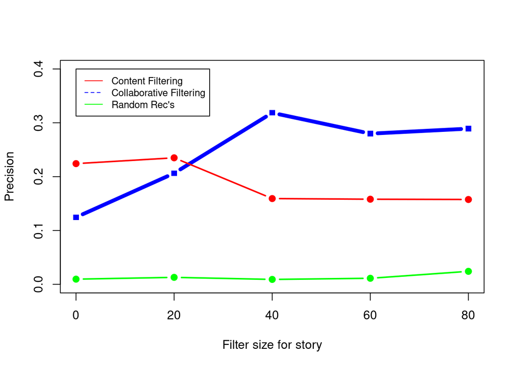

```r
plot(filter_sizes, precision_cf, ylim=c(0, 0.4), type="b", col="blue", lwd=5, pch=15, ylab="Precision", xlab="Filter size for story")
lines(filter_sizes, precision_con, type="b", col="red", lwd=2, pch=19)
lines(filter_sizes, precision_rand, type="b", col="green", lwd=2, pch=19)
legend(0, 0.4, legend=c("Content Filtering", "Collaborative Filtering", "Random Rec's"),
       col=c("red", "blue", "green"), lty=1:2, cex=0.8)
```

The x-axis represent the lower bound of the filter size; for example, “0” means we are retaining all stories with number of interactions in the range (0, 20), “20” means range (20, 40), and so on.

From the plot, we can see that the score for content filtering (red) generally falls with larger filters, while the score for collaborative filtering (blue) rises. This makes intuitive sense, since collaborative filtering doesn’t work well with stories with few interactions.

The two lines intersect when the filter size is the range 20-40; this means we should begin to use personalization when an item roughly reaches that many interactions.

### Exercises

**As to content filtering, one obvious way to improve its performance is to add new story characteristics. What characteristics can you think of that may help to improve the performance? These could be features obtained by combining existing features, or additional ones not present in the given dataset. How would you plan on collecting the data and testing the results?**